# P3-CP1

# Analise de grupos de filmes da Emma Watson

## Os dados

Como já foi mencionado acima, vamos analisar filmes da Emma Watson, vamos tentar descobrir grupos e nomea-los de forma que sejam descrito por esses nomes, e nos preocuparemos tambem em ecnontrar uma quantidade razoavel de grupos para que nao sejam perdidos dados (por exenplo, selecionar apenas 1 grupo de todos os filmes da Emma Watson e nomea-lo) e tambem nao podemos ter uma grande quantidade de grupos (aqui seria o inverso do caso anterior, muitos grupos gera muita informacao e muita informacao junta dificulta a intuicao sobre os grupos).  
Dados que utilizaremos do dataset:  
1. BOX OFFICE: receita do filme  
2. RATING: nota recebida pelo filme  
3. YEAR: ano de lancamento do filme

# Analise do dendograma

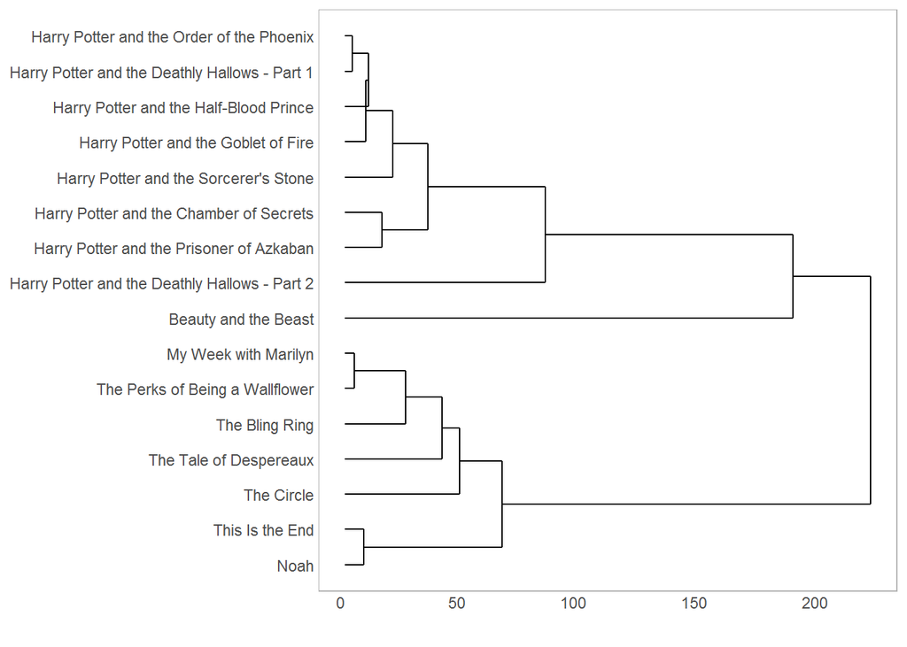

```r
agrupamento_h_2d = filmes %>%
    column_to_rownames("TITLE") %>%
    select(RATING, `BOX OFFICE`) %>%
    dist(method = "euclidean") %>%
    hclust(method = "centroid")

ggdendrogram(agrupamento_h_2d, rotate = TRUE)
```

Vemos acima uma grande dissimilaridade quando o algoritmos muda de 3 para 2 grupos, indicando 3 como uma quantidade razoavel de grupos para representar os filmes da Emma Watson.

## Analise de grafico de linha

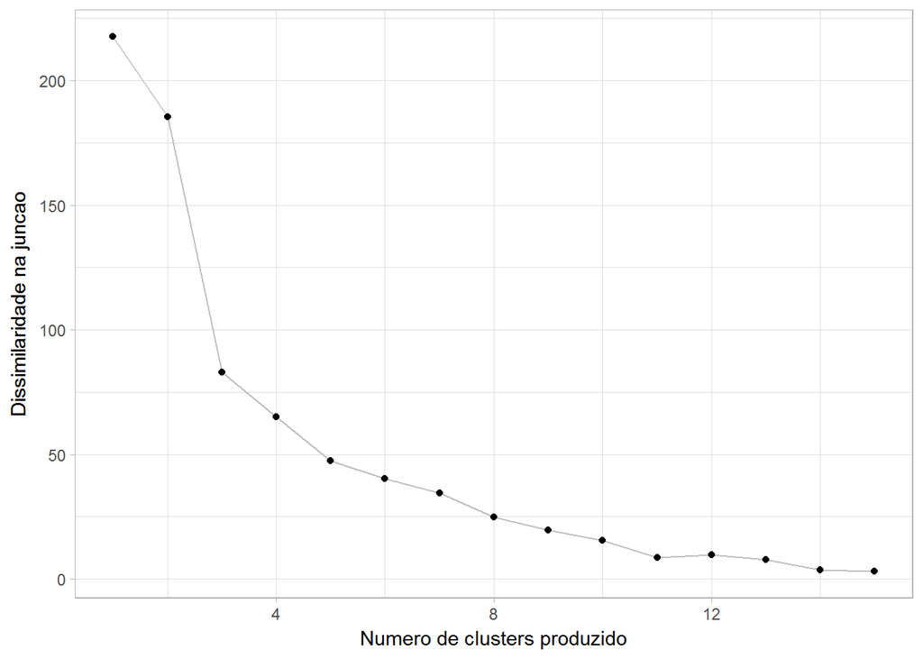

```r
data.frame(k = NROW(agrupamento_h_2d$height):1,
           height = agrupamento_h_2d$height) %>%
    ggplot(aes(x = k, y = height)) +
    geom_line(colour = "grey") +
    geom_point() +
    labs(x = "Numero de clusters produzido", y = "Dissimilaridade na juncao")
```

Nesse grafico podemos confirmar a afirmacao anterior, a dissimilaridade tenta a aumentar rapidamente quando o numero de clusters eh inferior a 3.

## Escala decima eh boa?

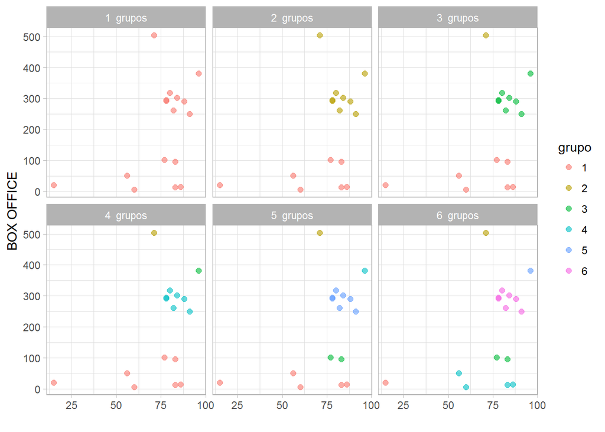

```r
plota_hclusts_2d(agrupamento_h_2d,
                 filmes,
                 c("RATING", "`BOX OFFICE`"),
                 linkage_method = "centroid", ks = 1:6)
```

Continuando a procurar pela quantidade de clusters ideal, vemos uma divisao para de 1 a 6 grupos, e percebemos que o de 3 grupos nos da impressao de uma boa divisao, visto que a escala de receita é bem maior que a de rating(nota). Entre os 3 grupos, podemos dividir em “Sucesso de bilheteria”, “Filmes com uma boa bilheteria” e “Fracassos de bilheteria”. Porém, estamos a analisar 2 variáveis e esses grupos nos deram apenas grupos que se dividem por bilheteria, esse nao seria o ideal, vamos tentar dividir melhor esses grupos a seguir:

[figure not shown]

```r
filmes2 = filmes %>% mutate(`BOX OFFICE` = log10(`BOX OFFICE`))
plota_hclusts_2d(agrupamento_h_2d,
                 filmes2,
                 c("RATING", "`BOX OFFICE`"),
                 linkage_method = "ward.D", ks = 3) + scale_y_log10()
```